# Time Series Analysics

## 111-1 Homework #02

> WANG, YIFAN (R10A21126@ntu.edu.tw)

> 2022-09-18

## > * I use R in Jupyter Notebook

## 1.

Take what you have simulated for the Q1 of HW#01 and add a proper disturbance to it, for example, $\epsilon_t \sim N (0, 0.1^2)$, to make it more fluctuating and, therefore, unpredictable. Now, let’s construct a mathematical model to predict it.

a. Extend the time series to $y_{54}$ using the same formula/procedures in HW#01.  
b. Yefine a proper disturbance for your time series.  
c. Identify the number of periods in a season and then deseasonalize the series using $y_1, y_2,\dots, y_{48}$.  
d. Calculate the seasonality factors (depending on how many periods in a season) using $y_1, y_2,\dots, y_{48}$.  
e. Finalize the model and validate the model performance via MSE and MAPE using $y_1, y_2,\dots, y_{48}$.  
f. Use the static model to calculate $ \hat{y}_{49},\hat{y}_{50},\dots,\hat{y}_{54} $. Compare with the ground truth of ${y}_{49}, y_{50},\dots,{y}_{54} $ and calculate the prediction MSE and MAPE accordingly.  
g. Modify the disturbance in (a) to change series (can be more or less fluctuating). Re-run the procedures (b)-(f). What can you conclude when comparing to the results in (e) & (f) with the previous disturbance.

```r
library(latex2exp)
```

## 1.a Without disturbance

$$Y_t = 20+t+10\sin\left[ \pi \left(\frac{1}{2}\cos\left(\frac{t}{2}\right)+1 \right)\right] \quad \text{for}\,\, t = 1,2,\dots,54$$

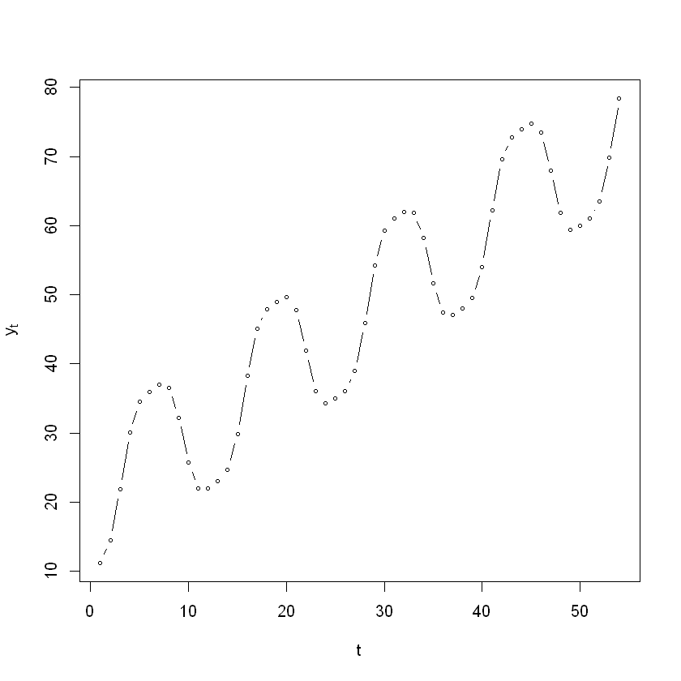

```r
y_t_a = array(54)
set.seed(23)
for (t in 1:54){
    y_t_a[t] = 20+t + 10*sinpi(cos(t/2)/2+1)
    }
plot(y_t_a,xlab = "t",ylab = TeX(r'($y_t$)'),type = 'b', cex = 0.5)
```

## 1.b With disturbance

$$Y_t = 20+t+10\sin\left[ \pi \left(\frac{1}{2}\cos\left(\frac{t}{2}\right)+1 \right)\right]+ \epsilon_t \quad \text{for}\,\, t = 1,2,\dots,54,$$

where $\epsilon_t$ is generated from a normal distribution $N(\mu = 0,\sigma= 10)$.

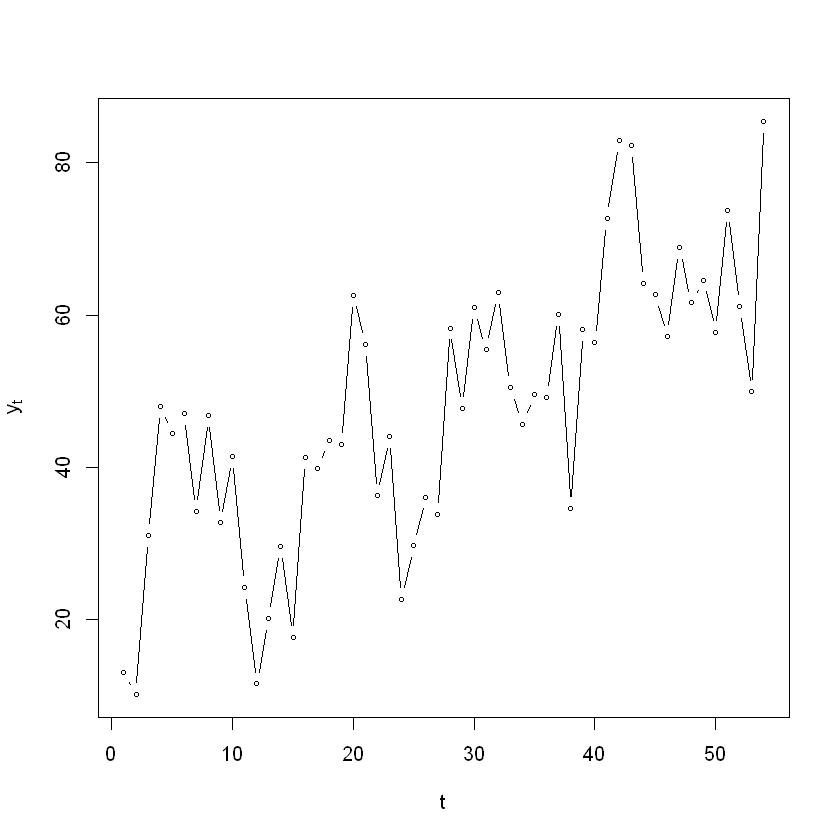

```r
y_t = array(54)
set.seed(23)
for (t in 1:54){
    y_t[t] = 20+t + 10*sinpi(cos(t/2)/2+1) + rnorm(1,mean = 0,sd = 10)
    }
plot(y_t,xlab = "t",ylab = TeX(r'($y_t$)'),type = 'b', cex = 0.5)
```

```r
y_t
```

1. 13.1164370711084

2. 10.1489287556822

3. 31.0238185883322

4. 48.015015077164

5. 44.4821520244021

6. 47.0736693472895

7. 34.1693647387173

8. 46.7482213177055

9. 32.7053698699927

10. 41.4480231407584

11. 24.2118209377626

12. 11.5542116966742

13. 20.1198751535529

14. 29.5534240937656

15. 17.6563868461846

16. 41.3470325915179

17. 39.9069220778366

18. 43.479584541564

19. 43.0067732250638

20. 62.6279726098902

21. 56.148110823505

22. 36.2703308615064

23. 44.0009733335115

24. 22.6399975605085

25. 29.691859741904

26. 36.0949066273609

27. 33.8313604626106

28. 58.2972884930595

29. 47.6849520582198

30. 60.9622012499553

31. 55.4622206502166

32. 62.9597055075933

33. 50.4604374962847

34. 45.6896547025791

35. 49.599782244763

36. 49.1650516432742

37. 60.1215586604571

38. 34.5722199380923

39. 58.1207848385037

40. 56.3486670112679

41. 72.6691015649333

42. 82.8718289095743

43. 82.2876868639141

44. 64.1437449394835

45. 62.6439543182224

46. 57.1341279733672

47. 68.8940367244605

48. 61.5980189646744

49. 64.5935846403642

50. 57.7054183718682

51. 73.669970002591

52. 61.114626015975

53. 49.8998245097115

54. 85.4402968242107

## 1.c

p = 12 (# of periods in a season)  
There are 12 periods in a season.  
Suppose we collect data every month, we have a 12-month season.

### De-seasonalize the series (using $y_1,y_2,\dots, y_{48}$)

$$ \bar{Y}_t = \begin{cases} \frac{\left[Y_{t-(\frac{p}{2})}+Y_{t+(\frac{p}{2})}+\sum^{t-1+(\frac{p}{2})}_{i = t+1-(\frac{p}{2})}2Y_i\right]}{2p} & p \text{ is even}\\ \frac{\sum^{t+(\frac{p-1}{2})}_{i = t-(\frac{p-1}{2})}Y_i}{p} & p \text{ is odd} \end{cases} $$

In this case ($p = 12$), for $7\leq t\leq 42$, we have $$\bar{Y}_t = \frac{\left[Y_{t-6}+Y_{t+6}+\sum^{t-1+6}_{i = t+1-6}2Y_i\right]}{2*12}$$

For $7\leq t\leq 42$, we run regression with $t$ and $\bar{Y}_t$ and get the coefficients  
L = 22.03068693  
T = 0.915279317

Then we have deseasonalized $ \hat{\bar{Y}}_t $ with $ \hat{\bar{Y}}_t = L+tT $ for $1\leq t\leq 48$

## 1.d

For $1\leq t\leq 48$

$$S_t = \frac{\bar{Y}_t}{\hat{\bar{Y}}_t} $$

Then we get the average of the seasonality effect for each period in a season as $\bar{S}_t$. For example, $\bar{S}_1 = \frac{1}{4}(S_1+S_{13}+S_{25}+S_{37})$. The values of $\bar{S}_t$ are the same for each season. They are also the same for the testing data.

## 1.e

For $1\leq t\leq 48$

$$\hat{Y}_t =\hat{\bar{Y}}_t * \bar{S}_t $$$$E_t = Y_t-\hat{Y}_t$$

We now caculate MSE and MAPE for $y_1,y_2,\dots, y_{48}$

MSE = 82.18  
MAPE = 20.30%

## 1.f

For $49\leq t\leq 54$

$$ \hat{\bar{Y}}_t = L+tT $$$$\hat{Y}_t =\hat{\bar{Y}}_t * \bar{S}_t $$$$E_t = Y_t-\hat{Y}_t$$

We now caculate MSE and MAPE for $y_{49},y_{50},\dots, y_{54}$

MSE = 495.07  
MAPE = 33.53%

### Conclusion

|  | MSE | MAPE |
| --- | --- | --- |
| Training | 82.18 | 20.30% |
| Testing | 495.07 | 33.53% |

# 1.g Modify the disturbance

$$Y_t = 20+t+10\sin\left[ \pi \left(\frac{1}{2}\cos\left(\frac{t}{2}\right)+1 \right)\right]+ \epsilon_t \quad \text{for}\,\, t = 1,2,\dots,54,$$

where $\epsilon_t$ is generated from a normal distribution $N(\mu = 0,\sigma= 5)$.

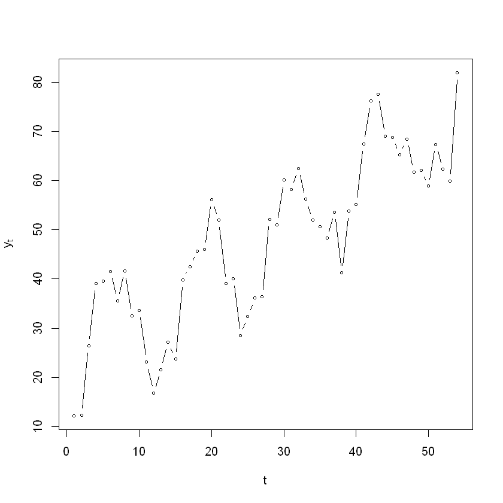

```r
y_t2 = array(54)
set.seed(23)
for (t in 1:54){
    y_t2[t] = 20 + t + 10*sinpi(cos(t/2)/2+1) + rnorm(1,mean = 0,sd = 5)
    }
plot(y_t2,xlab = "t",ylab = TeX(r'($y_t$)'),type = 'b', cex = 0.5)
```

```r
y_t2
```

1. 12.1503754016177

2. 12.3223392967157

3. 26.4574831053855

4. 39.0480746168464

5. 39.4991264902344

6. 41.536216910049

7. 35.55979615297

8. 41.65219387958

9. 32.478183976207

10. 33.5691251776304

11. 23.1203786833707

12. 16.7868884069022

13. 21.5633183942991

14. 27.145672667459

15. 23.738268981294

16. 39.8063481100693

17. 42.5078136527068

18. 45.6911535452512

19. 46.0033372849435

20. 56.1550834658869

21. 51.9711545865519

22. 39.1004063600147

23. 40.0588765833379

24. 28.4696441880689

25. 32.3459597731993

26. 36.1002003110737

27. 36.3941722883111

28. 52.0829509304767

29. 50.9878663152319

30. 60.1290801759325

31. 58.2282468509271

32. 62.4687984336425

33. 56.1937667959783

34. 51.9392909852197

35. 50.6103406575874

36. 48.2775500190621

37. 53.5833220562836

38. 41.2868969608349

39. 53.8153696405998

40. 55.1842919956638

41. 67.4578160974281

42. 76.2263376387748

43. 77.5578970966603

44. 69.0718724602757

45. 68.7232884839386

46. 65.2801576522158

47. 68.432455531897

48. 61.7086060801294

49. 62.0261950784773

50. 58.8531865619676

51. 67.3623904855087

52. 62.306804211463

53. 59.8888875491921

54. 81.9349170338442

Repeat the steps above

|  | MSE | MAPE |
| --- | --- | --- |
| Training | 46.33 | 13.33% |
| Testing | 270.95 | 23.63% |

### In general, the model performs better for data with smaller fluctuation.

## 2.

Construct the Holt-Winter’s model (Triple Exponential Smoothing model) for the same data in 1-(a) using $y_1, y_2,\dots, y_{48}$. Try to find the smoothing factors with better performance. Explain what you observe comparing with the results in 1-(e) & 1-(f)

We use the $L_t$ first model in EXCEL  
$L_0,T_0$ are from the regression model

## SMOOTHING FACTORS WITH BETTER PERFORMANCE

| Smoothing constant | Value |
| --- | --- |
| $\alpha$ | 0.09 |
| $\beta$ | 0.79 |
| $\gamma$ | 0.84 |

|  | MSE | MAPE |
| --- | --- | --- |
| Training | 346.69 | 28.92% |
| Testing | 221.47 | 20.46% |

The validation data has greater fluctuation (worse MSE and MAPE) while the model performs better for testing data.